# Session 04: What is affective polarization?

Tristan Muno

October 14, 2026

## Session 04 goals

By the end of today, you will be able to:

1. Derive in-group favouritism and out-group hostility from social identity theory.
2. Explain what affective polarization claims to add to an ideological account of division.
3. Assess the evidence that partisan animus shows up in implicit attitudes and behavior, and not only in what people say in surveys.

## Today

1. **Why groups?**
   - An evolutionary reading
2. **Categories in the head**
   - Why we see borders where there are none
3. **Social identity theory**
   - Ingroup favouritism and outgroup derogation
4. **Iyengar, Sood and Lelkes (2012)**
   - “Affect, not ideology”
5. **Iyengar and Westwood (2015)**
   - “Fear and loathing across party lines”
6. **Wrap-up**

# Why groups?

## Group membership

- Belonging is a fundamental human need, not a taste (Baumeister and Leary 1995)
- Our large brains co-evolved with living in large groups (Dunbar 1993)
- A group means an **ingroup** (share, cooperate) and an **outgroup** (compete, beware)

## An old species

- *Homo sapiens* is roughly **300,000** years old (Hublin et al. 2017)
- Modern behaviour built up gradually, with no sudden “revolution” (McBrearty and Brooks 2000)
- For almost all of that time: small, mobile bands of a few dozen adults (Hill et al. 2011)
- The same minds now live in democracies of millions

# Categories in the head

## Invented borders

Once we sort a continuum into categories, we

- **overestimate** differences *between* categories
- **underestimate** differences *within* them

Label lines “A” and “B”, and people see the gap between A and B as larger (Tajfel and Wilkes 1963)

## The colour example

- The spectrum is continuous
- The colour names, and the borders between them, are ours

[figure not shown]

Figure 1: The visible spectrum, roughly 400 to 700 nm. The light changes continuously, and every border between named colours is drawn by us. *Source:* Wikimedia Commons, public domain.

## From categories to bias

- The same distortion, applied to people
- *Them*: all alike, and very unlike us
- *Us*: a collection of individuals (Quattrone and Jones 1980)

# Social identity theory

## Tajfel and Turner

Social identity is the part of the self that comes from group membership (Tajfel and Turner 1986)

1. **Categorisation**: sort people, yourself included
2. **Identification**: the group becomes part of who you are
3. **Comparison**: judge *us* against *them*

We seek **positive distinctiveness**: our group should look better

## Minimal groups

- Assign people to groups on a trivial basis: Klee vs Kandinsky, dot estimates
- No history, no contact, no self-interest at stake
- People still favour their own group, and even trade gains to **widen the gap** (Tajfel 1970; Tajfel et al. 1971)
- It works even when assignment is openly random (Billig and Tajfel 1973)

## Two kinds of bias

- **Ingroup favouritism**: liking and helping *us*
- **Outgroup derogation**: disliking and hurting *them*
- Distinct, and the first does not require the second (Brewer 1999)
- In cooperation experiments, discrimination is mostly ingroup love (Balliet et al. 2014)
- Keep this in mind for Iyengar and Westwood

## Party as identity

- If a party is a group like any other, partisans are an *us*
- Then SIT predicts **affect**, not only disagreement: warmth for our side, hostility for theirs

> “the tendency of people identifying as [partisans] to view opposing partisans negatively and copartisans positively” (Iyengar and Westwood 2015, 691; Iyengar et al. 2019)

# Iyengar, Sood and Lelkes (2012)

## Introduction

- Last week’s debate asked whether *policy views* have moved apart
- ISL: that is the wrong test
- Look at how partisans **feel** about each other, as **social distance** (Bogardus 1947)

## Theory

- Party identification is a social identity
- Identity implies warmth for *us* and coldness toward *them*
- Campaigns make the identity **salient**, and negative ads feed the dislike

## Research design

- **Thermometers**: how warm do you feel toward each party? (ANES, 1978 to 2008)
- **Social distance**: traits of party supporters, a child marrying across party lines
- **Comparison**: United States vs United Kingdom, 1960 vs 2008 and 2010
- **Explanations**: policy attitudes, exposure to campaigns

## Results: thermometers

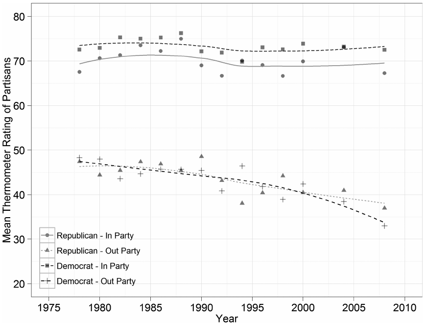

Figure 2: Mean feeling thermometer ratings of the own and the other party among Republicans and Democrats, ANES 1978 to 2008. In-party ratings stay near 70, out-party ratings fall toward 30. *Source:* Iyengar et al. (2012), Figure 1.

- It is the *out-party* that has changed

## Results: social distance

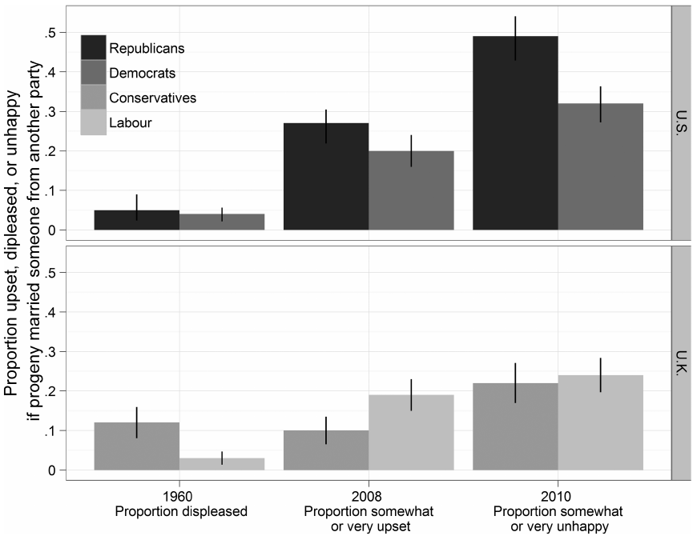

Figure 3: Share of partisans upset, displeased or unhappy if their child married a supporter of the other party, United States (top) and United Kingdom (bottom), 1960, 2008 and 2010. The US share rises from about 5% to between a third and a half. *Source:* Iyengar et al. (2012), Figure 4.

- Policy views explain little of this, campaigns a little

## Conclusion

- **Affect, not ideology**: Americans dislike the other side more, without disagreeing much more
- Partisanship is an affective bond more than a set of views
- Risk: opponents’ decisions may stop counting as legitimate

# Iyengar and Westwood (2015)

## Introduction

- ISL showed what partisans *say*
- Survey answers can be filtered or exaggerated
- Does animus show up where people **cannot hide it**, and in **nonpolitical choices**?

## Theory

- Benchmark: **race**, the deepest American divide
- Social norms restrain racial bias, no norm restrains partisan bias
- Expect partisan bias to be automatic, as large as racial bias, and driven by **dislike** of the out-party

## Research design

1. **Implicit**: reaction-time test of party and race associations
2. **Scholarship**: choose between two students, one cue for party or race, grades varied
3. **Games**: split $10 with a copartisan or opponent, same or other race
4. **Games with a control**: separate favour for *us* from hostility to *them*

[figure not shown]

Figure 4: The partisan brief implicit association test. Respondents sort party images and good or bad words with two keys, as fast as they can. *Source:* Iyengar and Westwood (2015), Figure 1.

## Results: does the test work?

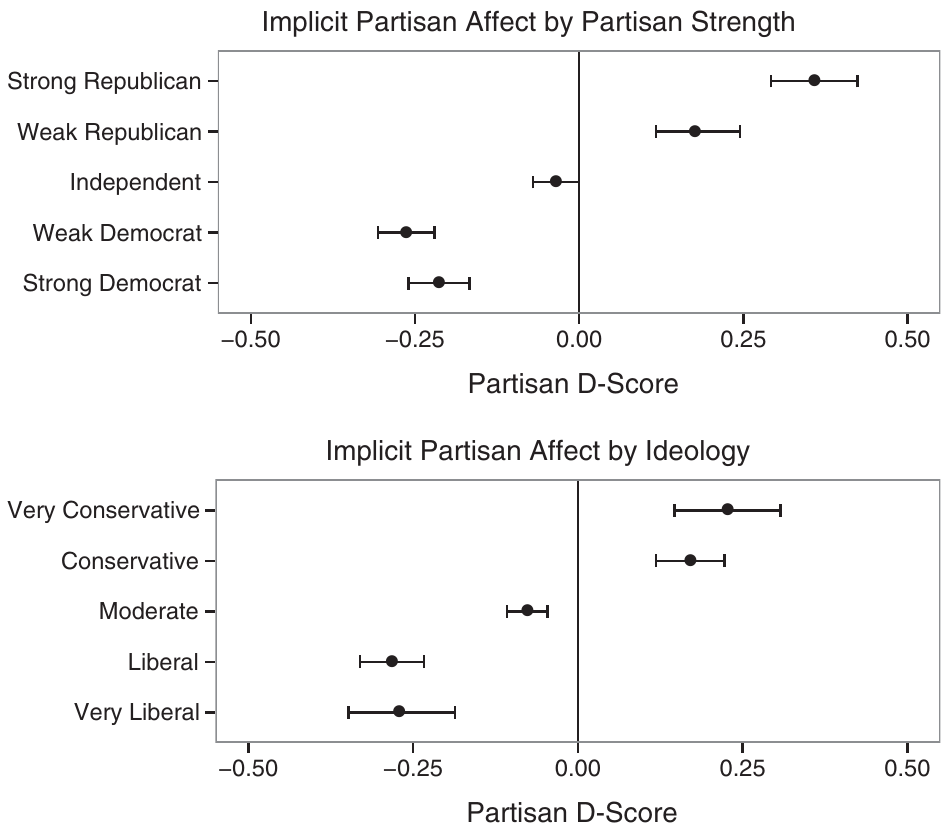

Figure 5: Mean partisan D-score with 95% confidence intervals, by strength of party identity (top) and by ideology (bottom). The implicit preference follows self-reported party and ideology. *Source:* Iyengar and Westwood (2015), Figure 2.

- The implicit measure sorts people the way their self-reports do

## Results: saying vs reacting

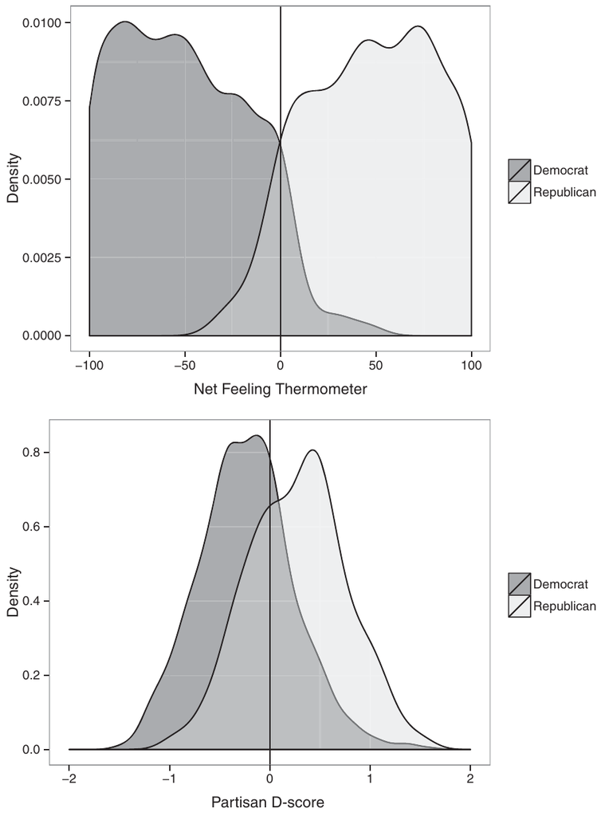

- Explicit answers are **more** polarized than automatic reactions

## Results: party vs race

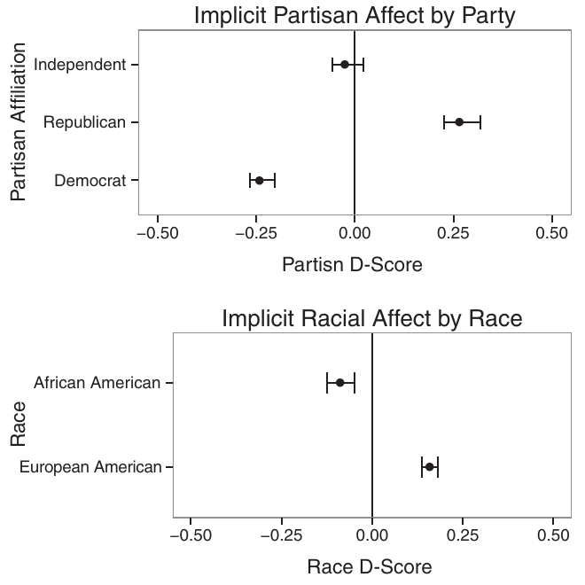

Figure 7: Implicit association scores for party (top) and race (bottom), means with 95% confidence intervals. Democrats and Republicans lie further apart than African and European Americans. *Source:* Iyengar and Westwood (2015), Figure 4.

- The party gap is **larger** than the race gap, even implicitly

## Results: leaners

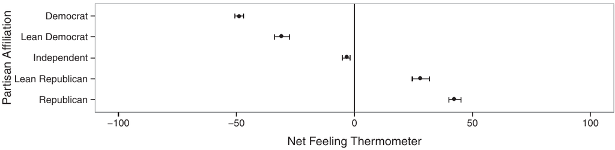

Figure 8: Mean net feeling thermometer, Republicans minus Democrats, with 95% confidence intervals, by party identity including leaners and pure independents. Leaners sit close to the partisans, pure independents near zero. *Source:* Iyengar and Westwood (2015), Figure 5.

- Leaners behave like partisans, only pure independents are neutral

## Results: scholarship

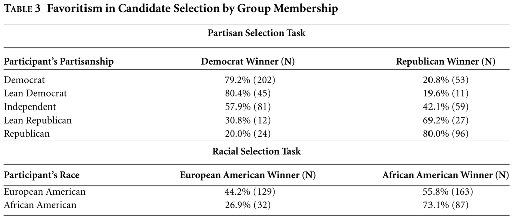

Figure 9: Winner of the scholarship by the participant’s party (top) and race (bottom). About 80% of partisans pick the candidate of their own party, while race produces far weaker ingroup choice. *Source:* Iyengar and Westwood (2015), Table 3.

- Four in five partisans pick their own side

## Results: merit and party

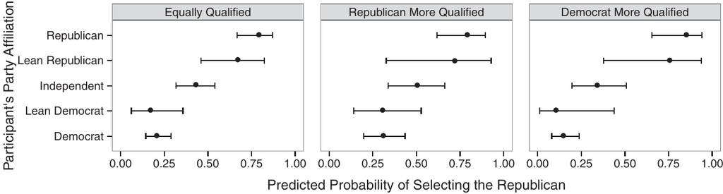

Figure 10: Predicted probability of picking the Republican, by participant’s party, for equally qualified candidates and for each candidate being more qualified. Partisan choices barely respond to grades. *Source:* Iyengar and Westwood (2015), Figure 6.

- Grades barely move partisan choices

## Results: merit and race

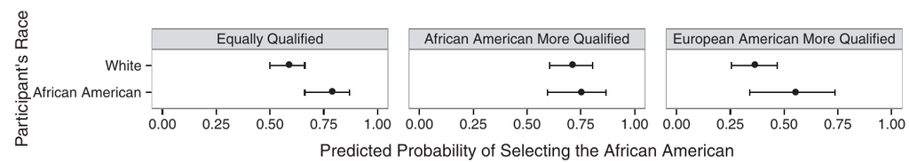

Figure 11: Predicted probability of picking the African American, by participant’s race, for equally qualified candidates and for each candidate being more qualified. Racial choices respond to grades. *Source:* Iyengar and Westwood (2015), Figure 7.

- Party trumps merit, race does not

## Results: games

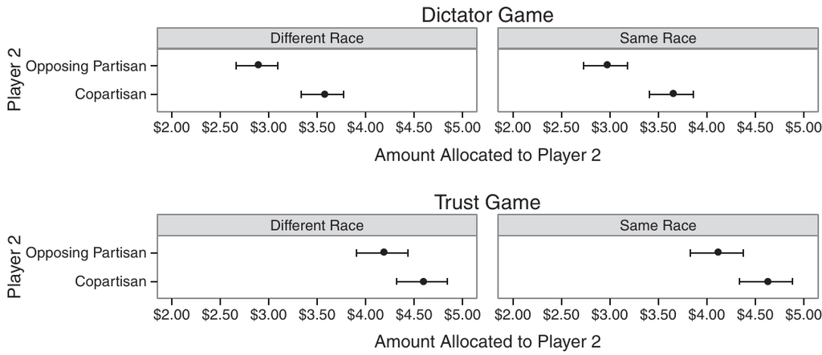

Figure 12: Mean amount of $10 given to player 2 in dictator (top) and trust (bottom) games, by player 2’s party and race, with 95% confidence intervals. Copartisans receive more than opponents in both games, while race makes no difference. *Source:* Iyengar and Westwood (2015), Figure 8.

- With real money at stake, party matters and race does not

## Results: by party

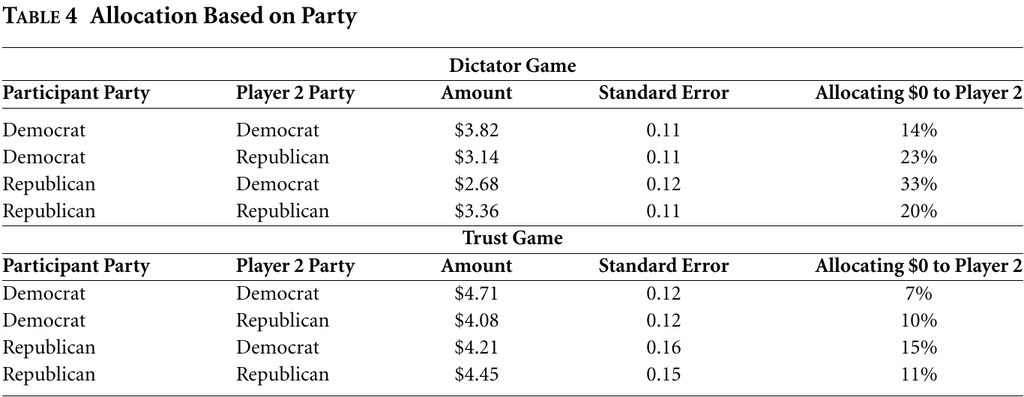

Figure 13: Mean amount given to player 2, with standard errors and the share giving nothing, by the participant’s and player 2’s party, in the dictator and trust games. Both parties give more to their own side. *Source:* Iyengar and Westwood (2015), Table 4.

- The bias is symmetric: each side gives its own about 68 cents more in the dictator game

## Results: love or hate?

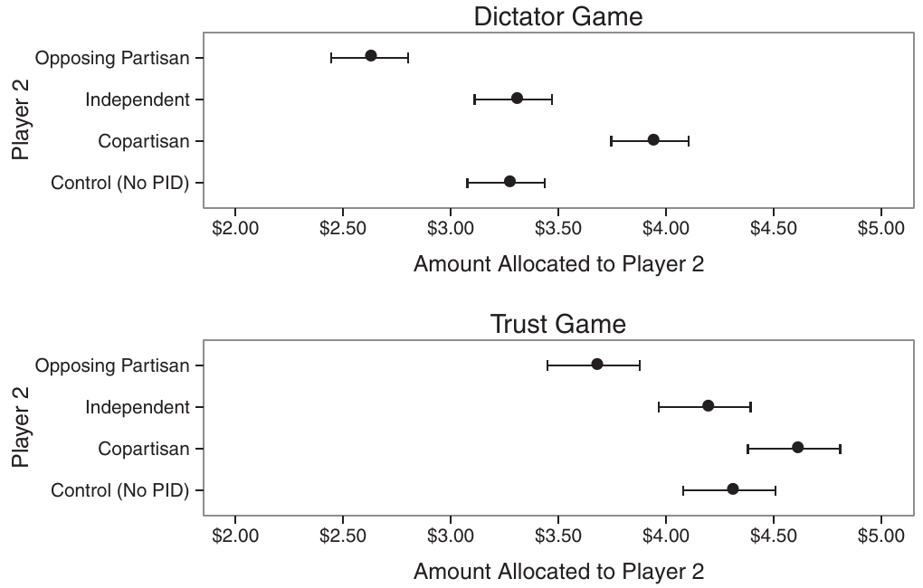

Figure 14: Amount of $10 given to player 2 in dictator and trust games, by player 2’s party, means with 95% confidence intervals. Opponents receive less than the no-information control, copartisans more. *Source:* Iyengar and Westwood (2015), Figure 9.

- In the trust game the penalty for opponents is about **twice** the bonus for copartisans

## Conclusion

- The party divide is as deep as race, or deeper, and it reaches **nonpolitical** choices
- It is **permitted**: no norm restrains it
- Hostility toward *them* outweighs favour for *us*
- Elites have an incentive to fight rather than cooperate

# Wrap-up

## Recap: takeaways

- Groups are old, and categories distort how we see people
- Social identity theory: a category alone is enough for bias
- Affective polarization: dislike of the other side, measured apart from policy views
- In the US it has grown since the 1980s, while in-party warmth stayed flat
- It shows up implicitly and in behaviour, and exceeds racial bias

## Recap: learning goals

**Goal 1. Favouritism and hostility from social identity theory**

- Categorisation, identification, comparison, and the wish for positive distinctiveness
- Favouritism and derogation are distinct. Party seems to trigger both.

**Goal 2. What affect adds to ideology**

- Division can grow in feelings while policy views stay put
- ISL: out-party ratings fall, policy attitudes explain little

**Goal 3. Animus beyond survey answers**

- Implicit tests and costly choices show the same bias, with no norm to restrain it

## Next session

- **Session 05: Measuring affective polarization**
- Today we asked whether it exists. Next we ask how well our measures capture it.
- Core reading: Druckman and Levendusky (2019) and Wagner (2021)

## References

Balliet, Daniel, Junhui Wu, and Carsten K. W. De Dreu. 2014. “Ingroup Favoritism in Cooperation: A Meta-Analysis.” *Psychological Bulletin* 140 (6): 1556–81. https://doi.org/10.1037/a0037737.

Baumeister, Roy F., and Mark R. Leary. 1995. “The Need to Belong: Desire for Interpersonal Attachments as a Fundamental Human Motivation.” *Psychological Bulletin* 117 (3): 497–529. https://doi.org/10.1037/0033-2909.117.3.497.

Billig, Michael, and Henri Tajfel. 1973. “Social categorization and similarity in intergroup behaviour.” *European Journal of Social Psychology* 3 (1): 27–52. https://doi.org/10.1002/ejsp.2420030103.

Bogardus, Emory S. 1947. “Measurement of Personal-Group Relations.” *Sociometry* 10 (4): 306–11. https://doi.org/10.2307/2785570.

Brewer, Marilynn B. 1999. “The Psychology of Prejudice: Ingroup Love and Outgroup Hate?” *Journal of Social Issues* 55 (3): 429–44. https://doi.org/10.1111/0022-4537.00126.

Druckman, James, and Matthew Levendusky. 2019. “What Do We Measure When We Measure Affective Polarization?” *Public Opinion Quarterly* 83 (1): 114–22. https://doi.org/10.1093/poq/nfz003.

Dunbar, Robin I. M. 1993. “Coevolution of Neocortical Size, Group Size and Language in Humans.” *Behavioral and Brain Sciences* 16 (4): 681–94. https://doi.org/10.1017/S0140525X00032325.

Hill, Kim R., Robert S. Walker, Miran Božičević, et al. 2011. “Co-Residence Patterns in Hunter-Gatherer Societies Show Unique Human Social Structure.” *Science* 331 (6022): 1286–89. https://doi.org/10.1126/science.1199071.

Hublin, Jean-Jacques, Abdelouahed Ben-Ncer, Shara E. Bailey, et al. 2017. “New Fossils from Jebel Irhoud, Morocco and the Pan-African Origin of Homo sapiens.” *Nature* 546 (7657): 289–92. https://doi.org/10.1038/nature22336.

Iyengar, Shanto, Yphtach Lelkes, Matthew Levendusky, Neil Malhotra, and Sean J. Westwood. 2019. “The Origins and Consequences of Affective Polarization in the United States.” *Annual Review of Political Science* 22 (1): 129–46. https://doi.org/10.1146/annurev-polisci-051117-073034.

Iyengar, Shanto, Gaurav Sood, and Yphtach Lelkes. 2012. “Affect, Not Ideology: A Social Identity Perspective on Polarization.” *Public Opinion Quarterly* 76 (3): 405–31. https://doi.org/10.1093/poq/nfs038.

Iyengar, Shanto, and Sean J. Westwood. 2015. “Fear and Loathing Across Party Lines: New Evidence on Group Polarization.” *American Journal of Political Science* 59 (3): 690–707. https://doi.org/10.1111/ajps.12152.

McBrearty, Sally, and Alison S. Brooks. 2000. “The Revolution That Wasn’t: A New Interpretation of the Origin of Modern Human Behavior.” *Journal of Human Evolution* 39 (5): 453–563. https://doi.org/10.1006/jhev.2000.0435.

Quattrone, George A., and Edward E. Jones. 1980. “The Perception of Variability Within in-Groups and Out-Groups: Implications for the Law of Small Numbers.” *Journal of Personality and Social Psychology* 38 (1): 141–52. https://doi.org/10.1037/0022-3514.38.1.141.

Sapolsky, Robert M. 2017. *Behave: The Biology of Humans at Our Best and Worst*. Penguin Press.

Tajfel, Henri. 1970. “Experiments in Intergroup Discrimination.” *Scientific American* 223 (5): 96–103. https://www.jstor.org/stable/24927662.

Tajfel, Henri, Michael G. Billig, Robert P. Bundy, and Claude Flament. 1971. “Social Categorization and Intergroup Behaviour.” *European Journal of Social Psychology* 1 (2): 149–78. https://doi.org/10.1002/ejsp.2420010202.

Tajfel, Henri, and John C. Turner. 1986. “The Social Identity Theory of Intergroup Behavior.” In *Psychology of Intergroup Relation*, 2nd ed., edited by Stephen Worchel and William G. Austin. Nelson Hall.

Tajfel, Henri, and A. L. Wilkes. 1963. “Classification and Quantitative Judgement.” *British Journal of Psychology* 54 (2): 101–14. https://doi.org/10.1111/j.2044-8295.1963.tb00865.x.

Wagner, Markus. 2021. “Affective Polarization in Multiparty Systems.” *Electoral Studies* 69: 102199. https://doi.org/10.1016/j.electstud.2020.102199.